# Practical 8

Matteo Larrode

2024-01-8

# Week 8: Regression Discontinuity Designs

We analyze Erik Meyersson’s 2014 paper, “Islamic Rule and the Empowerment of the Poor and Pious.” He asks whether political control by Islamic religious political parties leads to a decrease in women’s rights, particularly female education rates. He looks at Turkey in 1994, where an Islamic party gained political control in many municipalities, and a number of the election results were very close. He uses a regression discontinuity analysis of Islamic control on the rate of secondary school completion by girls, focusing on the Local Average Treatment Effect in areas where Islamic parties barely won or lost their elections.

```r
library(tidyverse)
library(rdd)
m <- read_csv("data/islamic.csv")
```

```
## ──────────────────────────────────────────────────────── Delimiter: "," dbl
## (7): ...1, iwm94, hischshr1520m, hischshr1520f, lpop1994, sexr, lareapre
```

**a) Create a treatment variable, islamicwin, that indicates whether or not the Islamic party won the 1994 election.**

```r
 m$islamicwin<-ifelse(m$iwm94>=0,1,0)
```

**b) Calculate the difference in means in secondary school completion rates for women between regions where Islamic parties won and lost in 1994. Do you think this is a credible estimate of the causal effect of Islamic party control? Why or why not?**

```r
mean(m$hischshr1520f[m$islamicwin==1],na.rm=T) - mean(m$hischshr1520f[m$islamicwin==0],na.rm=T)
```

```
## [1] -0.02577901
```

The answer is -0.0258. A naive interpretation of this would be that Islamic party control leads to lower female education rates. But this is not a very credible estimate of the causal effect, due to selection bias. The treated and untreated regions are likely to have very different potential outcomes. For example, it is likely that places that strongly support Islamic parties are less supportive of female education to begin with.

**c) Now we’ll start regression discontinuity analysis. First, calculate the optimal bandwidth for testing female high school completion rates using the Imbens-Kalyanaram procedure. Explain what the bandwidth means in this case.**

```r
band <- IKbandwidth(m$iwm94, m$hischshr1520f)
```

This gives a bandwidth of 0.240. It means the optimal bias-variance tradeoff is achieved in this RD analysis by only including regions where the vote share margin for the Islamic Party was in the interval [−0.24, 0.24]

**d) Use RD estimation to find the Local Average Treatment Effect of Islamic party control on women’s secondary school education at the threshold, using local linear regression estimated with the RDestimate function from the rdd package (it will automatically use the bandwidth calculated in part c). Interpret the LATE carefully in words.**

```r
rdest <- RDestimate(hischshr1520f~iwm94,data=m)

summary(rdest)
```

```
##
## Call:
## RDestimate(formula = hischshr1520f ~ iwm94, data = m)
##
## Type:
## sharp
##
## Estimates:
##            Bandwidth  Observations  Estimate  Std. Error  z value  Pr(>|z|)
## LATE       0.2398     1020          0.02963   0.01241     2.388    0.01694   *
## Half-BW    0.1199      589          0.02502   0.01646     1.520    0.12859
## Double-BW  0.4796     2050          0.02279   0.01009     2.257    0.02399   *
## ---
## Signif. codes:  0 '***' 0.001 '**' 0.01 '*' 0.05 '.' 0.1 ' ' 1
##
## F-statistics:
##            F       Num. DoF  Denom. DoF  p
## LATE        4.990  3         1016        3.865e-03
## Half-BW     1.703  3          585        3.304e-01
## Double-BW  25.770  3         2046        4.441e-16
```

This gives a LATE estimate of 0.0296 with a p value of 0.017, indicating that the effect is clearly significant at the 5% level. This implies that, for regions close to the cutoff, an election win by an Islamic party leads to an increase in the secondary school completion rate for girls of 2.96 percentage points.

**e) Perform placebo tests to check that the relationship between the running variable and outcome is not fundamentally discontinuous, by estimating RD estimates at placebo cutoffs of -0.1, -0.05, 0.05 and 0.1. What do you conclude?**

```r
summary(RDestimate(hischshr1520f~iwm94,cutpoint=-0.1,data=m))
```

```
##
## Call:
## RDestimate(formula = hischshr1520f ~ iwm94, data = m, cutpoint = -0.1)
##
## Type:
## sharp
##
## Estimates:
##            Bandwidth  Observations  Estimate  Std. Error  z value  Pr(>|z|)
## LATE       0.17346     991          -0.03956  0.012944    -3.056   0.0022410
## Half-BW    0.08673     540          -0.04242  0.017625    -2.407   0.0160853
## Double-BW  0.34691    1892          -0.03135  0.009371    -3.346   0.0008209
##
## LATE       **
## Half-BW    *
## Double-BW  ***
## ---
## Signif. codes:  0 '***' 0.001 '**' 0.01 '*' 0.05 '.' 0.1 ' ' 1
##
## F-statistics:
##            F       Num. DoF  Denom. DoF  p
## LATE        9.993  3          987        3.434e-06
## Half-BW     6.934  3          536        2.769e-04
## Double-BW  25.046  3         1888        1.332e-15
```

```r
summary(RDestimate(hischshr1520f~iwm94,cutpoint=-0.05,data=m))
```

```
##
## Call:
## RDestimate(formula = hischshr1520f ~ iwm94, data = m, cutpoint = -0.05)
##
## Type:
## sharp
##
## Estimates:
##            Bandwidth  Observations  Estimate  Std. Error  z value  Pr(>|z|)
## LATE       0.2133     1062          0.010914  0.011406    0.9568   0.3386
## Half-BW    0.1066      602          0.023427  0.015327    1.5285   0.1264
## Double-BW  0.4266     2030          0.003022  0.009101    0.3320   0.7399
## ---
## Signif. codes:  0 '***' 0.001 '**' 0.01 '*' 0.05 '.' 0.1 ' ' 1
##
## F-statistics:
##            F       Num. DoF  Denom. DoF  p
## LATE        6.427  3         1058        5.171e-04
## Half-BW     4.933  3          598        4.320e-03
## Double-BW  22.963  3         2026        2.576e-14
```

```r
summary(RDestimate(hischshr1520f~iwm94,cutpoint= 0.05,data=m))
```

```
##
## Call:
## RDestimate(formula = hischshr1520f ~ iwm94, data = m, cutpoint = 0.05)
##
## Type:
## sharp
##
## Estimates:
##            Bandwidth  Observations  Estimate   Std. Error  z value  Pr(>|z|)
## LATE       0.2428      894           0.008425  0.01381      0.6100  0.5419
## Half-BW    0.1214      477          -0.008693  0.01902     -0.4569  0.6477
## Double-BW  0.4855     1860           0.015888  0.01074      1.4788  0.1392
## ---
## Signif. codes:  0 '***' 0.001 '**' 0.01 '*' 0.05 '.' 0.1 ' ' 1
##
## F-statistics:
##            F        Num. DoF  Denom. DoF  p
## LATE        0.9997  3          890        7.845e-01
## Half-BW     0.6825  3          473        8.739e-01
## Double-BW  20.6232  3         1856        7.636e-13
```

```r
summary(RDestimate(hischshr1520f~iwm94,cutpoint= 0.1,data=m))
```

```
##
## Call:
## RDestimate(formula = hischshr1520f ~ iwm94, data = m, cutpoint = 0.1)
##
## Type:
## sharp
##
## Estimates:
##            Bandwidth  Observations  Estimate  Std. Error  z value  Pr(>|z|)
## LATE       0.4292     1374          0.022748  0.01335     1.7037   0.08845   .
## Half-BW    0.2146      657          0.015799  0.01714     0.9216   0.35675
## Double-BW  0.8585     2613          0.008147  0.01119     0.7282   0.46646
## ---
## Signif. codes:  0 '***' 0.001 '**' 0.01 '*' 0.05 '.' 0.1 ' ' 1
##
## F-statistics:
##            F       Num. DoF  Denom. DoF  p
## LATE       10.370  3         1370        1.898e-06
## Half-BW     1.851  3          653        2.733e-01
## Double-BW  21.017  3         2609        3.770e-13
```

At -0.05 and 0.05 there is no evidence of a discontinuous relationship (the p-values are very high, indiciating no evidence of an RD “effect” at those placebo cutoffs). However, at -0.1 there is strong evidence of a discontinuity, and at 0.1 there is some evidence (a statistically significant effect exists at the 10% level). This constitutes evidence against a true RD effect because it indicates that the discontinuity we measured at 0 could be only one of many discontinuities in the data. In other words, the effect at 0 could have arisen due to chance alone.

```r
summary(RDestimate(sexr~iwm94, data=m))
```

```
##
## Call:
## RDestimate(formula = sexr ~ iwm94, data = m)
##
## Type:
## sharp
##
## Estimates:
##            Bandwidth  Observations  Estimate    Std. Error  z value   Pr(>|z|)
## LATE       0.2332     1026          -0.0001991  0.01599     -0.01245  0.9901
## Half-BW    0.1166      595           0.0142670  0.01904      0.74949  0.4536
## Double-BW  0.4664     2017           0.0040372  0.01319      0.30600  0.7596
##
## LATE
## Half-BW
## Double-BW
## ---
## Signif. codes:  0 '***' 0.001 '**' 0.01 '*' 0.05 '.' 0.1 ' ' 1
##
## F-statistics:
##            F       Num. DoF  Denom. DoF  p
## LATE       0.2341  3         1022        0.2547
## Half-BW    1.0347  3          591        0.7533
## Double-BW  0.4251  3         2013        0.5299
```

```r
summary(RDestimate(lpop1994~iwm94, data=m))
```

```
##
## Call:
## RDestimate(formula = lpop1994 ~ iwm94, data = m)
##
## Type:
## sharp
##
## Estimates:
##            Bandwidth  Observations  Estimate  Std. Error  z value  Pr(>|z|)
## LATE       0.19247     890           0.06921  0.2384       0.2903  0.7716
## Half-BW    0.09624     482          -0.04339  0.3276      -0.1324  0.8946
## Double-BW  0.38494    1663           0.03000  0.1879       0.1597  0.8732
## ---
## Signif. codes:  0 '***' 0.001 '**' 0.01 '*' 0.05 '.' 0.1 ' ' 1
##
## F-statistics:
##            F       Num. DoF  Denom. DoF  p
## LATE       0.9344  3          886        0.84690
## Half-BW    0.5508  3          478        0.70434
## Double-BW  3.0843  3         1659        0.05277
```

```r
summary(RDestimate(lareapre~iwm94, data=m))
```

```
##
## Call:
## RDestimate(formula = lareapre ~ iwm94, data = m)
##
## Type:
## sharp
##
## Estimates:
##            Bandwidth  Observations  Estimate  Std. Error  z value  Pr(>|z|)
## LATE       0.2406     1034           0.07112  0.1780       0.3996  0.6894
## Half-BW    0.1203      599           0.04630  0.2300       0.2013  0.8405
## Double-BW  0.4812     2070          -0.07522  0.1466      -0.5130  0.6080
## ---
## Signif. codes:  0 '***' 0.001 '**' 0.01 '*' 0.05 '.' 0.1 ' ' 1
##
## F-statistics:
##            F       Num. DoF  Denom. DoF  p
## LATE       0.8430  3         1030        0.940779
## Half-BW    0.5899  3          595        0.756345
## Double-BW  5.6850  3         2066        0.001421
```

There is no evidence of discontinuities for these any of these variables. They all have small placebo LATE estimates and high p-values. This suggests that, at least based on these observed covariates, there was no sorting around the threshold: local randomisation is likely to hold.

**g) Perform a McCrary test: another way to check for sorting at the theshold. Plot and interpret the results.**

```r
DCdensity(m$iwm94, verbose =TRUE)
```

```
## Assuming cutpoint of zero.
## Using calculated bin size:  0.009
## Using calculated bandwidth:  0.165
```

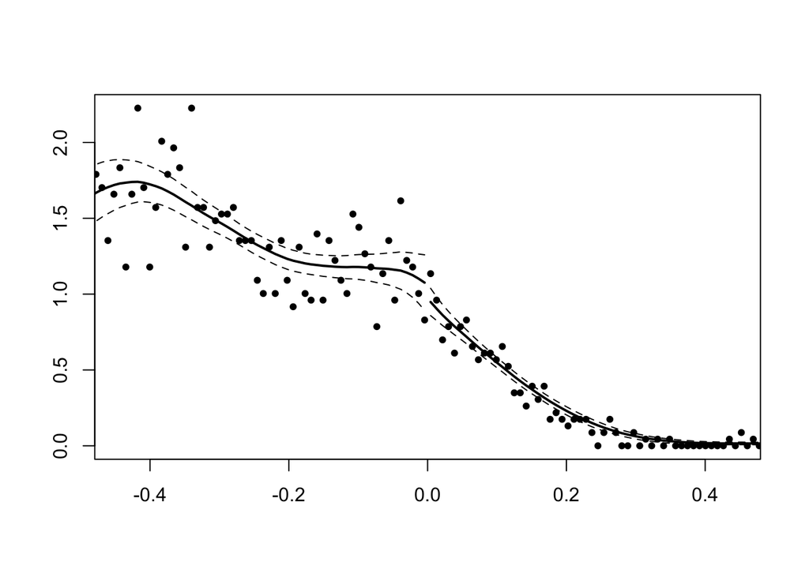

```
## Log difference in heights is  -0.095  with SE  0.147
##   this gives a z-stat of  -0.650
##   and a p value of  0.515
```

```
## [1] 0.5153874
```

The p-value for the resultant test statistic is 0.515, meaning that we cannot reject the null hypothesis of no discontinuous jump in the density of the running variable. Visually, you can also see that there is no strong evidence for this in the plot.

**h) Examine the sensitivity of the main RD result to the choice of bandwidth by calculating and plotting RD estimates and their associated 95% confidence intervals for a range of bandwidths from 0.05 to 0.6. To what extent do the results depend on the choice of bandwidth?**

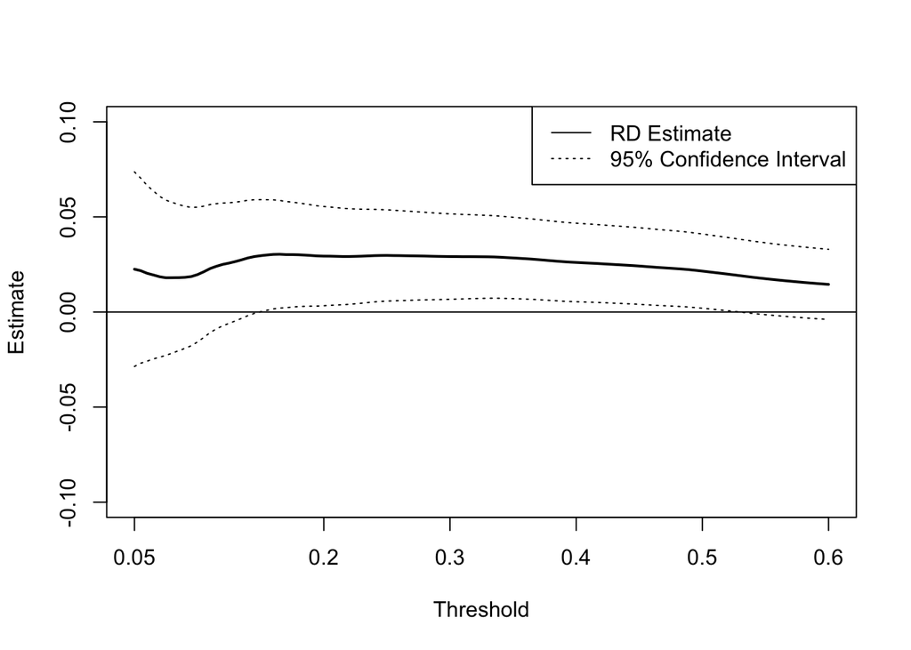

```r
rdests <- c()
rdci.up <- c()
rdci.down <- c()

thresholds <- seq(from=0.05,to=0.6,by=0.005)

for(i in 1:length(thresholds)){
 rdest <- RDestimate(hischshr1520f~iwm94, bw=thresholds[i], data=m)
 rdests[i] <- rdest$est[1]
 rdci.up[i] <- rdests[i] + 1.96*rdest$se[1]
 rdci.down[i] <- rdests[i] -1.96*rdest$se[1]
}

plot(rdests,
     type="l",
     lwd=2,
     ylim=c(-0.1,0.1),
     xaxt="n",
     xlab="Threshold",
     ylab="Estimate")
axis(1,
     at=c(1,31,51,71,91,111),
     labels=c(0.05,0.2,0.3,0.4,0.5,0.6))
abline(h=0)
lines(rdci.up,
      lty=3)
lines(rdci.down,
      lty=3)
legend("topright", c("RD Estimate","95% Confidence Interval"), lty=c(1,3))
```

The plot shows a fairly typical pattern in RD analysis. At very low bandwidths, very little data is used in estimation, making the variance very high. Unsurprisingly therefore, the confidence interval is very wide at low bandwidths: recall that the optimal IK bandwidth is chosen with the twin goals in mind of reducing bias and variance. As the threshold (and therefore the effective sample size) increases, the confidence interval decreases.

The size of the RD estimate does not change much as the bandwidth increases, which is reassuring. We would not want our result to be extremely sensitive to the bandwidth choice. Its statistical significance does change somewhat as the threshold changes. It is significant at the 95% level for bandwidths between approximately 0.15 and 0.55, becoming statistically indistinguishable from 0 again at higher bandwidths. Again, this is reassuring, because the main result holds across a wide range of bandwidths, and it would not be very defensible in the first place to do RD estimation with a bandwidth as high as 0.55, where we are using data that is very far indeed from the cutoff. Overall, if you saw this plot in a published paper you should feel reassurred that the author’s results are not driven primarily by the choice of threshold.